# Tarea 2: descenso en gradiente

```r
library(tidyverse)
```

En el siguiente problema queremos predecir el porcentaje de grasa corporal (que es relativamente costoso de medir) en términos de distintas medidas del cuerpo (estatura, peso, circunferencia de abdomen, etc.) Usaremos [estos datos](http://jse.amstat.org/v4n1/datasets.johnson.html). Las medidas corporales están estandarizadas.

```r
bodyfat <- read_csv('../datos/bodyfat_est.csv')
```

Vamos a ajustamos un modelo lineal de la forma:

$grasacorp ~ b_0 + b_1 estatura + b_2 abdomen + b_3 muñeca + b_4 rodilla$

### Parte 1: separar muestra de entrenamiento y de prueba:

Separa los datos a la mitad: 50% de entrenamiento y 50% de prueba aproximadamente:

```r
set.seed(92311)
bodyfat$id <- 1:nrow(bodyfat)
bodyfat$unif <- runif(nrow(bodyfat), 0, 1)
dat_ent <- bodyfat %>% filter(unif < 0.5)
dat_pr <- bodyfat %>% filter(unif >= 0.5)
dim(dat_ent)
```

```
## [1] 118  16
```

```r
dim(dat_pr)
```

```
## [1] 134  16
```

**Pregunta**: ¿Por qué en este ejemplo no sería buena idea tomar, por ejemplo, 90% de datos para entrenamiento y 10% para prueba?

### Parte 2: Calcula algunos resúmenes de los datos de entrenamiento

Calcula al menos mínimo, máximo y algunos percentiles para las variables *estatura*, *abdomen*, *muñeca* y *grasacorp*. Por ejemplo:

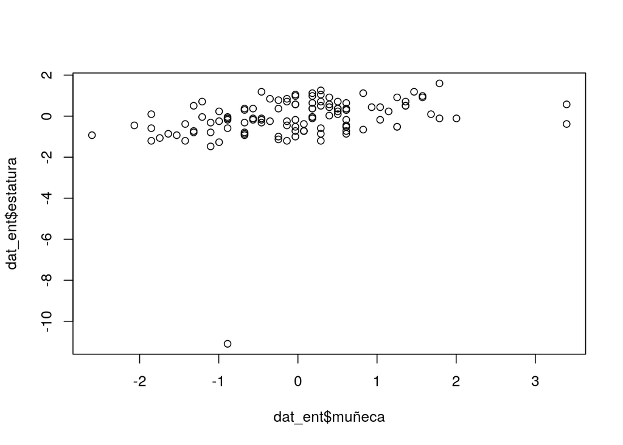

```r
plot(dat_ent$muñeca, dat_ent$estatura)
```

**Pregunta**: ¿Ves algunos datos problemáticos o posiblemente erróneos? Si los ves, ¿qué piensas que podría ser una buena estrategia para tratarlos?

Parece que hay un dato de estatura erróneo. Ninguna de sus mediciones son excepcionales, excepto - podemos excluirlo y establecer una regla en el preprocesamiento de datos, lo mejor es investigarlo.

```r
dat_ent <- filter(dat_ent, estatura > -10)
```

### Parte 3: Ajusta un modelo líneal usando descenso en gradiente

Puedes usar estas funciones, o escribir el código tu mismo:

```r
error_calc <- function(x, y){
  # x es un data.frame o matrix con entradas
  # y es la respuesta
  error_fun <- function(beta){
    # esta funcion debe devolver rss
    y_hat <- as.matrix(cbind(1,x)) %*% beta
    # residual
    e <- y - y_hat
    error <- 0.5*mean(e^2)
    error
  }
  error_fun
}


grad_calc <- function(x, y){
  # devuelve una función que calcula el gradiente para
  # parámetros beta
  # x es un data.frame o matrix con entradas
  # y es la respuesta
  grad_fun <- function(beta){
      # para este cálculo, ver notas
      f_beta <- as.matrix(cbind(1, x)) %*% beta
      e <- y - f_beta
      gradiente <- - apply(t(cbind(1,x)) %*% e, 1, mean)
      names(gradiente)[1] <- 'Intercept'
      gradiente
    }
   grad_fun
}


descenso <- function(n, z_0, eta, h_grad){
  # esta función calcula n iteraciones de descenso en gradiente
  z <- matrix(0,n, length(z_0))
  z[1, ] <- z_0
  for(i in 1:(n-1)){
    z[i+1,] <- z[i,] - eta * h_grad(z[i,])
  }
  z
}
```

```r
x_ent <- dat_ent %>% select(estatura, abdomen, muñeca, rodilla)
x_pr <- dat_pr %>% select(estatura, abdomen, muñeca, rodilla)
y_ent <- dat_ent$grasacorp
y_pr <- dat_pr$grasacorp
```

**Pregunta**: Rellena el siguiente código:

```r
gradiente <- grad_calc(x_ent, y_ent)
error <- error_calc(x_pr , y_pr)
```

**Pregunta**: ¿cuál es un valor de número de iteraciones (n) y tamaño de paso (eta) para este problema? ¿Qué pasa si haces eta demasiado grande?

Ahora **selecciona un valor del tamaño de paso** y corre descenso en gradiente:

```r
n <- 1000 ### rellena aquí un valor apropiado
eta <- 0.001 ## rellena aquí un valor apropiado
salida <- descenso(n, c(0,0,0,0,0), eta, gradiente)
salida
```

```
##              [,1]         [,2]     [,3]         [,4]      [,5]
##    [1,]  0.000000  0.000000000 0.000000  0.000000000 0.0000000
##    [2,]  2.308200  0.041618580 1.071423  0.517792818 0.8519400
##    [3,]  4.334049  0.001103768 1.825975  0.791413344 1.3881017
##    [4,]  6.114492 -0.086044346 2.372290  0.912154043 1.7209273
##    [5,]  7.680800 -0.197532598 2.780780  0.938501379 1.9229728
##    [6,]  9.059706 -0.319528722 3.097154  0.907809546 2.0410457
##    [7,] 10.274252 -0.443604403 3.351149  0.843832087 2.1053328
##    [8,] 11.344410 -0.564768071 3.562173  0.761579802 2.1352929
##    [9,] 12.287580 -0.680200532 3.742942  0.670452925 2.1434617
##   [10,] 13.118966 -0.788443734 3.901841  0.576259589 2.1379073
##   [11,] 13.851890 -0.888881524 4.044439  0.482515658 2.1238160
##   [12,] 14.498048 -0.981408412 4.174477  0.391280971 2.1045156
##   [13,] 15.067724 -1.066219273 4.294503  0.303696600 2.0821357
##   [14,] 15.569964 -1.143676724 4.406286  0.220329390 2.0580342
```

[output cut: 986 more lines]

Grafica el error para cada iteración para checar convergencia:

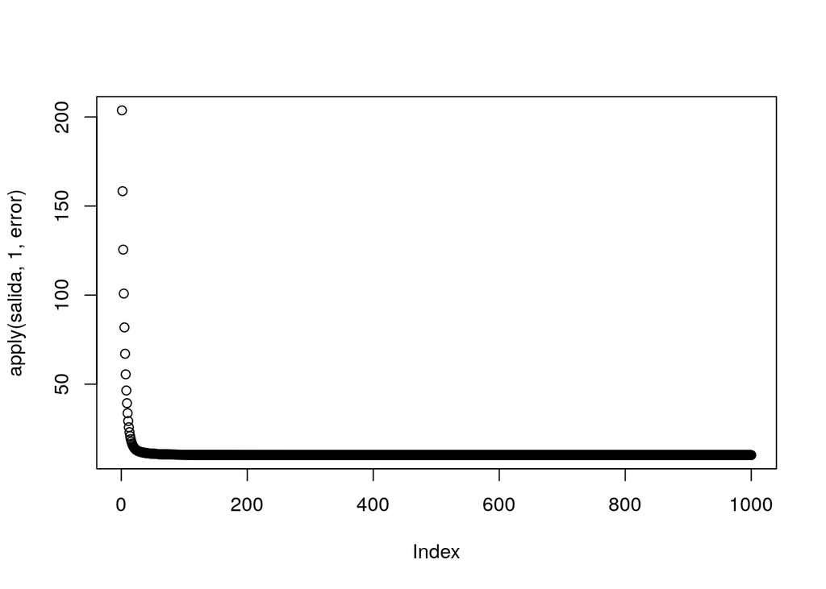

```r
## Aquí tu código
plot(apply(salida, 1, error))
```

## Checa con lm

**Pregunta**: ¿Obtienes los mismos coeficientes *beta* si usas, por ejemplo, la función *lm*?

```r
mod_1 <- lm(grasacorp ~  estatura +  abdomen + muñeca + rodilla, data = dat_ent)
beta <- coef(mod_1)
beta
```

```
## (Intercept)    estatura     abdomen      muñeca     rodilla
##  19.2914306  -1.1804180   7.2032424  -1.3480847   0.5321569
```

### Parte 4: Evalúa con muestra de prueba

**Pregunta**: ¿cuál es el error en muestra de prueba? ¿cómo se compara con el error de entrenamiento?

Eevaluamos con la muestra de prueba:

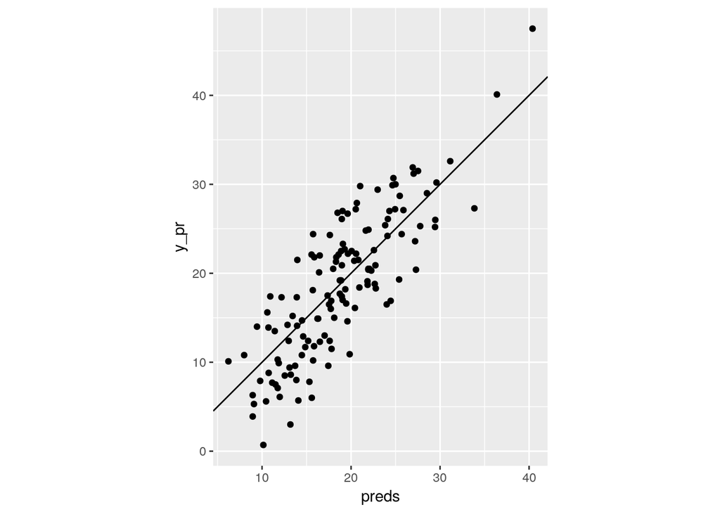

```r
calcular_preds <- function(x, beta){
  as.matrix(cbind(1, x)) %*% beta
}
beta <- beta
preds <- calcular_preds(x_pr, beta)
# grafica predicciones vs observados
qplot(x = preds, y = y_pr) + geom_abline(intercept = 0, slope = 1) + coord_equal()
```

```r
error_prueba <- mean((y_pr - preds)^2)
sqrt(error_prueba)
```

```
## [1] 4.518219
```

Este número podemos interpretarlo en la escala de la variable que queremos predecir (está en porcentaje).

También podemos evaluar otro tipo de errores que pueden interpretarse más fácilmente, por ejemplo, la media del las diferencias en valores absolutos:

```r
mean(abs(y_pr - preds))
```

```
## [1] 3.82528
```

**Pregunta**: ¿Cómo se compara este error con la variación que existe en la variable grasa corporal?

El error de entrenamiento es:

```r
mean(abs(fitted(mod_1) - y_ent))
```

```
## [1] 3.543717
```